# Mini-Project 2

```r
load("house_elections.rda")
load("candidates.rda")
load("committees.rda")
load("contributions.rda")
```

```r
contributions_alt <- contributions %>%
  filter(transaction_type == "24E",
         transaction_pgi == "G2012")%>%
  select(cmte_id, transaction_type, entity_type, transaction_pgi, name, state, transaction_amt, cand_id, file_num)

#This chunk creates a new dataset called "contributions_alt" that filters for "24E" (independent expenditure advocating election of candidate) and "G2012" (2012 General Election). It also only includes variables that are relevant to further analyses.
```

```r
candidates_alt <- candidates %>%
  filter(cand_election_yr == "2012", cand_office == "P")

candidates_alt$cand_name <- gsub("ROMNEY, MITT / RYAN, PAUL D.", "ROMNEY, MITT", candidates_alt$cand_name)


#This chunk creates a new dataset called "candidates_alt" that filters for "2012" (2012 election round) and "P" (Presidential election race). This way, both "contributions_alt" and "candidates_alt" only include data from the General Election of 2012.
```

```r
joined_table <- contributions_alt %>%
  full_join(candidates_alt, by = "cand_id") %>%
  filter(entity_type == "IND", state == "CA") %>%
  group_by(state, cand_name) %>%
  summarize(avg_donation = mean(transaction_amt))%>%
  na.omit

#This chunk joins the two datasets just created. It filters for only donations which have an entity classified as "IND" representing individuals from "CA", California. The variable transaction_amt is summarized to calculate the average donation for each candidate by state. The new dataset that results from this join is called "joined_table" and returns two observations of three variables. We have successfully calculated how much money individuals in California donated on average to Barack Obama and Mitt Romney's 2012 Presidential Campaigns.
```

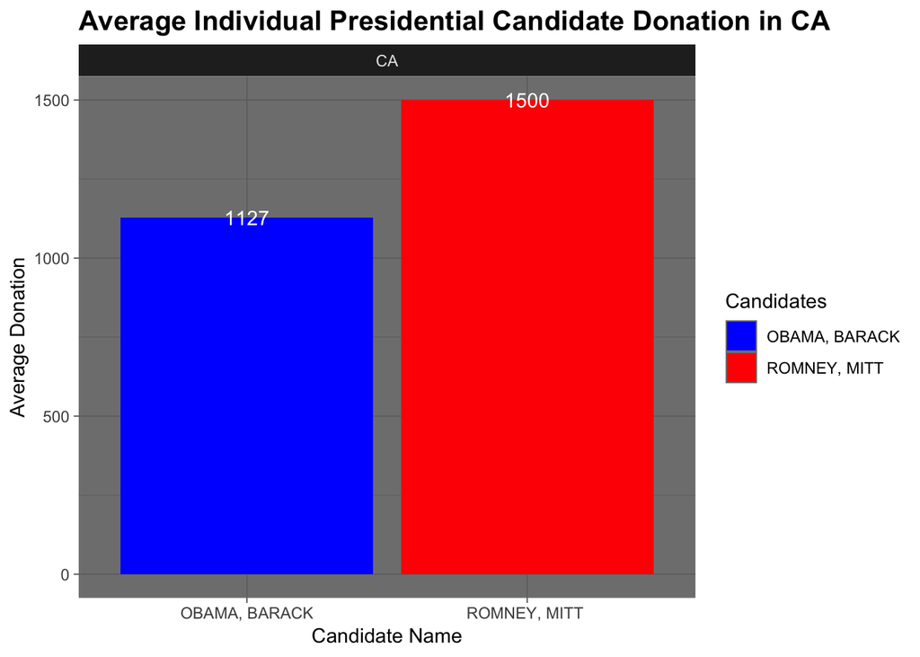

```r
individual_contributions <- ggplot(joined_table, aes(x=cand_name, y=avg_donation, fill = cand_name))+
  geom_col()+
  geom_text(aes(label=round(avg_donation, digits = 2)), color = "white")+
  facet_wrap(~state, scales='free_x', ncol = 5)+
  guides(fill=guide_legend(title="Candidates"))+
  xlab("Candidate Name")+
  ylab("Average Donation")+
  theme(legend.position = "none")+
  scale_fill_manual(values = c("blue","red"))+
  theme(axis.text.x = element_text(size=5),
        axis.text.y = element_text(size=5))+
  labs(title = "Average Individual Presidential Candidate Donation in CA")+
  theme_dark()+
  theme(plot.title = element_text(face="bold", size=15))

individual_contributions
```

```r
#This chunk creates a bar graph that portrays the average donation Obama and Romney received from individuals in the state of California during the 2012 Presidential Campaign. As mentioned before, these donations only include those advertising for each candidate.
```

```r
functionname <- function(name_arg) {
  contributions_alt %>%
  full_join(candidates_alt, by = "cand_id") %>%
  filter(entity_type == name_arg, state == "CA") %>%
  na.omit
}

#This chunk creates a function that joins candidates_alt and contributions_alt but can additionally filter for any donation entity type we ask it to. This way, we can study more entity types.
```

```r
entity_types <- c("IND", "ORG", "CCM")

#The entity types we have chosen to study are individual, organization, and candidate committee.
```

```r
mapped_function <- map(entity_types, functionname)
mapped_function <- bind_rows(mapped_function)

new_mapped_function <- mapped_function %>%
  group_by(entity_type, cand_name) %>%
  summarize(avg_donation = mean(transaction_amt))

#This creates a table called new_mapped_function that calculates the average donation for each type of entity per candidate.
```

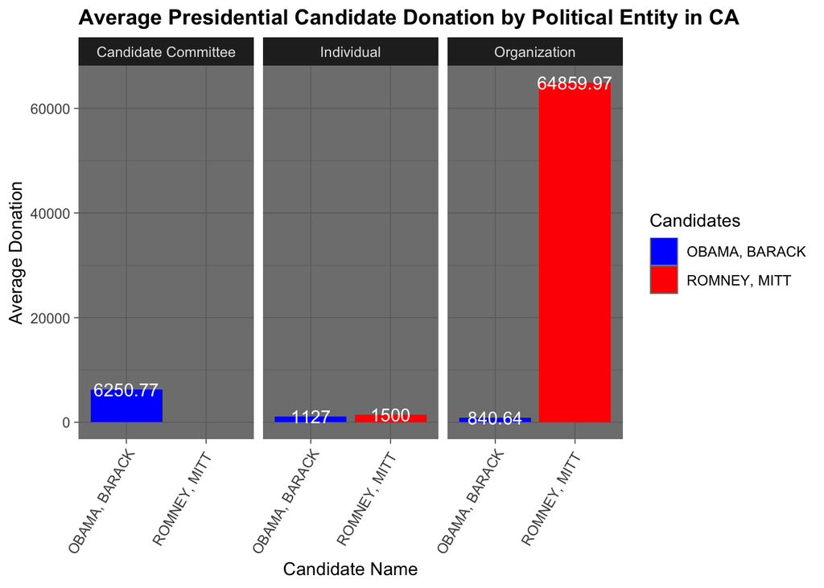

```r
final_plot <- ggplot(new_mapped_function, aes(x=cand_name, y=avg_donation, fill = cand_name))+
  geom_col() +
  scale_fill_manual(values = c("blue","red"))+
  facet_wrap(~entity_type, ncol = 3, nrow=1, scales = "fixed", shrink = TRUE, labeller(entity_type=
      c("CCM" = "Candidate Committee",
        "IND" = "Individual",
        "ORG" = "Organization"))) +
  xlab("Candidate Name")+
  ylab("Average Donation")+
  guides(fill=guide_legend(title="Candidates"))+
  geom_text(aes(label=round(avg_donation, digits = 2)), color = "white")+
  labs(title = "Average Presidential Candidate Donation by Political Entity in CA")+
  theme_dark()+
  theme(axis.text.x = element_text(angle=60, hjust = 1))+
  theme(plot.title = element_text(face="bold", size=13))


final_plot
```

This data compare the average 24E donation from individual, organization, and candidate committees for the top Presidential candidate from the Democratic and Republican political parties in the general 2012 election.

The first graph is a depiction of the average campaign contribution by individuals to the specified candidates, Barack Obama and Mitt Romney from the state of California.

The second graph is this same type of data wrangling applied to all three types of political entities that are allowed to give money to political candidates during elections: Candidate Committees, Political Organizations, and Individuals. This graph has been faceted to provide clarity when attempting to discern between each type of political entity. The candidates’ names are tilted at an angle, so as to enhance readability when placed together in more narrow columns.

The state of California is used specifically because it is the state that gave the largest amount of donation money overall in the election, as well as being considered the state that is considered a significant political powerhouse, holding the greatest populous and the most electoral votes.

The data is filtered to only include the Democratic and Republican parties because these are most prevalent parties that are discussed each election year. Any other parties’ impacts, such as the Independent party (IND), or the Green party (GRE) on the election are significantly smaller. The colors blue and red are designated to the candidates Obama and Romney because these are the main colors of their respective political parties; blue being associated with the Democratic (DEM) party and red being associated with the Republican (REP) party.

This information provides historical context to the 2012 election, as well as important information that could be used by party advertising in future elections. The Democratic party should attempt to cater more towards individuals with more of a middle/lower-class background, while the Republicans would find more source-funding from their comfort zone as well: the upper class individuals and organizations. California should be targeted by both parties, as it is a major source of financial support, and despite being historically blue, the state is not a solely blue monetary provider.

[^1]

[^1]: Github Repository: https://github.com/HannahRWang/sds192-mp2